# Tenth Week: Principal Component Analysis and Factor Analysis

PCA Stock, image, …

student name

2018-05-20 07:29:59

> با استفاده از داده های OHLCV شرکت های تشکیل دهنده شاخص s&p500 و همچنین داده مربوط به شاخص های اقتصادی به سوالات زیر پاسخ دهید.

۱. چه شرکتی رکورددار کسب بیشترین سود در بازه یکساله، دو ساله و پنج ساله می باشد؟ این سوال را برای بخش های مختلف مورد مطالعه قرار دهید و رکورددار را معرفی کنید. (برای این کار به ستون sector داده constituents مراجعه کنید.) برای هر دو قسمت نمودار سود ده شرکت و یا بخش برتر را رسم نمایید.

```r
setwd('/media/saleh/New Volume/study/uni/8/data science/HW/hw_09')
library(data.table)
library(dplyr)
```

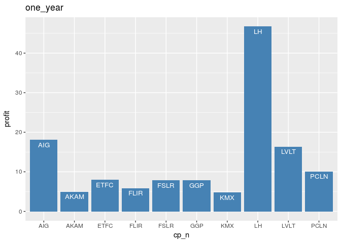

```r
library(tidyr)
library(ggplot2)
library(reshape2)
comp_name = list.files('./stock_dfs',pattern="*.csv",full.names=F)
filenames = list.files('./stock_dfs',pattern="*.csv",full.names=TRUE)
All <- lapply(filenames,function(i){
read.csv(i, header=T)
})
all_cmp_temp <- data.frame()

for (i in 1:length(All)){
  temp <- All[[i]]
  cp_n <- comp_name[[i]]
  cp_n <- gsub(pattern = "\\.csv$", "", cp_n)
  cp_n <- rep(cp_n,dim(temp)[1])
  temp$cp_n <- cp_n
  all_cmp_temp <- rbind(all_cmp_temp,temp)
}

all_cmp <- separate(all_cmp_temp, "Date", c("Year", "Month", "Day"), sep = "-")
all_cmp$Date <- all_cmp_temp$Date

cmp_name <- unique(all_cmp$cp_n)
cmp_count = length(cmp_name)

one_year <- data.frame(profit=rep(0,505),cp_n = cmp_name)
two_year <- data.frame(profit=rep(0,505),cp_n = cmp_name)
five_year <- data.frame(profit=rep(0,505),cp_n = cmp_name)

for (i in 1:length(cmp_name)){
  all_cmp %>%
    filter(cp_n == cmp_name[i]) %>% select(Year) %>% unique() -> cmp_year
  for (j in 1:length(cmp_year$Year)){
    all_cmp %>%
      filter(cp_n == cmp_name[i]) %>% filter(Year==cmp_year$Year[j])  -> init_year
     all_cmp %>%
      filter(cp_n == cmp_name[i]) %>% filter(Year==as.character(as.integer(cmp_year$Year[j])+0))  -> last_year
     if (nrow(last_year)!=0){
        diff = (tail(last_year,1)$Close - head(init_year,1)$Open) /  head(init_year,1)$Open
        if (diff > one_year$profit[one_year$cp_n==cmp_name[i]]){
          one_year$profit[one_year$cp_n==cmp_name[i]] <- diff
        }
     }

  }
}
one_year %>% arrange(-profit) %>% slice(1:10) %>%  ggplot(aes(x=cp_n,y=profit)) +
  geom_bar(stat="identity", fill="steelblue")+
  geom_text(aes(label=cp_n), vjust=1.6, color="white", size=3.5)+ ggtitle('one_year')
```

```r
  theme_minimal()
```

[output not shown]

[output cut: 306 more lines]

[output not shown]

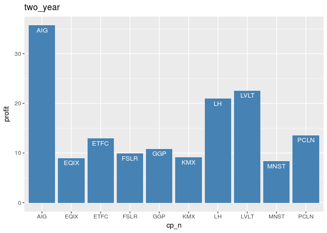

```r
##### two year
for (i in 1:length(cmp_name)){
  all_cmp %>%
    filter(cp_n == cmp_name[i]) %>% select(Year) %>% unique() -> cmp_year
  for (j in 1:length(cmp_year$Year)){
    all_cmp %>%
      filter(cp_n == cmp_name[i]) %>% filter(Year==cmp_year$Year[j])  -> init_year
     all_cmp %>%
      filter(cp_n == cmp_name[i]) %>% filter(Year==as.character(as.integer(cmp_year$Year[j])+1))  -> last_year
     if (nrow(last_year)!=0){
        diff = (tail(last_year,1)$Close - head(init_year,1)$Open) /  head(init_year,1)$Open
        if (diff > two_year$profit[two_year$cp_n==cmp_name[i]]){
          two_year$profit[two_year$cp_n==cmp_name[i]] <- diff
        }
     }

  }
}

  two_year %>% arrange(-profit) %>% slice(1:10) %>%  ggplot(aes(x=cp_n,y=profit)) +
  geom_bar(stat="identity", fill="steelblue")+
  geom_text(aes(label=cp_n), vjust=1.6, color="white", size=3.5)+ ggtitle('two_year')
```

```r
  theme_minimal()
```

[output not shown]

[output cut: 306 more lines]

[output not shown]

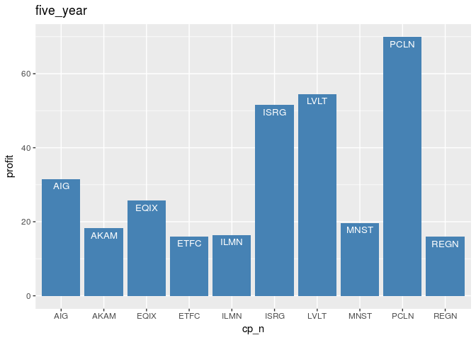

```r
##### five year
for (i in 1:length(cmp_name)){
  all_cmp %>%
    filter(cp_n == cmp_name[i]) %>% select(Year) %>% unique() -> cmp_year
  for (j in 1:length(cmp_year$Year)){
    all_cmp %>%
      filter(cp_n == cmp_name[i]) %>% filter(Year==cmp_year$Year[j])  -> init_year
     all_cmp %>%
      filter(cp_n == cmp_name[i]) %>% filter(Year==as.character(as.integer(cmp_year$Year[j])+4))  -> last_year
     if (nrow(last_year)!=0){
        diff = (tail(last_year,1)$Close - head(init_year,1)$Open) /  head(init_year,1)$Open
        if (diff > five_year$profit[five_year$cp_n==cmp_name[i]]){
          five_year$profit[five_year$cp_n==cmp_name[i]] <- diff
        }
     }

  }
}

  five_year %>% arrange(-profit) %>% slice(1:10) %>%  ggplot(aes(x=cp_n,y=profit)) +
  geom_bar(stat="identity", fill="steelblue")+
  geom_text(aes(label=cp_n), vjust=1.6, color="white", size=3.5)+ ggtitle('five_year')
```

```r
  theme_minimal()
```

[output not shown]

[output cut: 306 more lines]

[output not shown]

۲. یک اعتقاد خرافی می گوید خرید سهام در روز سیزدهم ماه زیان آور است. این گزاره را مورد ارزیابی قرار دهید.

i made a t test on day 13 and other data to see if there is any diffrence between these two group . I use High price for this test .

```r
all_cmp %>% mutate(curse = (Day==13)) ->is_curse
t.test(High~curse,data = is_curse,alternative='greater')
```

```
##
##  Welch Two Sample t-test
##
## data:  High by curse
## t = -0.10869, df = 70119, p-value = 0.5433
## alternative hypothesis: true difference in means is greater than 0
## 95 percent confidence interval:
##  -0.862419       Inf
## sample estimates:
## mean in group FALSE  mean in group TRUE
##            59.78707            59.84052
```

so we can not say 13 day of the month is cursed as we can not reject the null hipothesis that their mean are equal :)

۳. رکورد بیشترین گردش مالی در تاریخ بورس برای چه روزی بوده است و چرا!!!

```r
all_cmp_temp %>% mutate(turnover = Volume * abs(Close-Open)) %>% group_by(Date)%>% summarise(Day_turnover = sum(turnover)) %>% arrange(-Day_turnover) %>% slice(1)
```

```
## # A tibble: 1 x 2
##   Date       Day_turnover
##   <fct>             <dbl>
## 1 2008-10-10  25943598428
```

so 2008 10 10 is the day that we have most turn over :) its just because it was * US economic crisis **

۴. شاخص AAPL که نماد شرکت اپل است را در نظر بگیرید. با استفاده از رگرسیون خطی یک پیش کننده قیمت شروع (open price) بر اساس k روز قبل بسازید. بهترین انتخاب برای k چه مقداری است؟ دقت پیش بینی شما چقدر است؟

as it said in the class k can be max 10 here . in here 10 element of accuracy vector talk about accuracy of model for k days before. i assume model has k feature for each k .

```r
apple <- all_cmp %>% filter(cp_n=='AAPL') %>% select(Open)
model_res <- rep(0,10)
cols =  paste("x", 1:10, sep = "")
for (k in 1:10){
  day_count <- dim(apple)[1] - k
  day <- data.frame(y=tail(apple,day_count)$Open)
  for (j in 1:k){
    lst <- dim(apple)[1] - j
    day <-cbind(day,apple[(lst-day_count+1):(lst),])
  }
  colnames(day) <- c('y',cols[1:k])
  linearMod <- lm(y~., data=day)
  model_res[k]<- summary(linearMod)$r.squared
}
model_res
```

```
##  [1] 0.9968083 0.9968110 0.9968110 0.9968124 0.9968146 0.9968152 0.9968157
##  [8] 0.9968167 0.9968179 0.9968184
```

۵. بر روی داده های قیمت شروع شرکت ها الگوریتم pca را اعمال کنید. نمودار تجمعی درصد واریانس بیان شده در مولفه ها را رسم کنید. سه مولفه اول چند درصد از واریانس را تبیین می کند؟

for this question first I find commen day in all companies that is about 126 day for all 505 company .

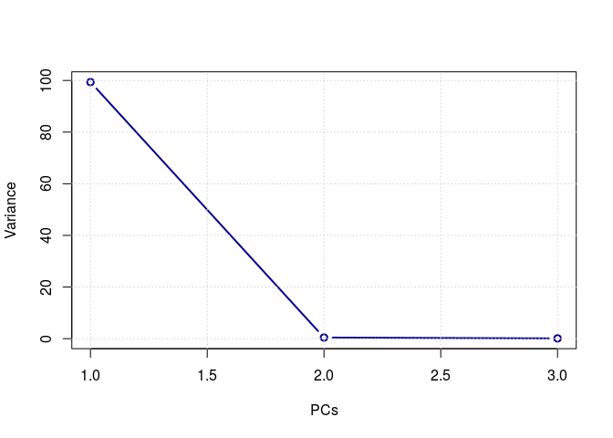

```r
all_cmp %>% group_by(Date) %>% filter(n()==505) -> commen
all_cmp %>% filter(Date %in% commen$Date) -> commen_all_cmp
commen_all_cmp %>% select(cp_n,Open,Date) -> op_com
op_com_mat <- acast(op_com, cp_n~Date, value.var="Open")
pca = prcomp(op_com_mat, center=T, scale.=T)
eigv = round(pca$sdev^2/sum(pca$sdev^2)*100, 2)
eigv = data.frame(c(1:126),eigv)
names(eigv) = c('PCs','Variance')
plot(eigv[1:3,],type = "b",col = "darkblue",lwd = 2);grid()
```

۶. برای هر نماد اطلاعات بخش مربوطه را از داده constituents استخراج نمایید. برای هر بخش میانگین روزانه قیمت شروع شرکت های آن را محاسبه کنید. سپس با استفاده از میانگین به دست آمده داده ایی با چند ستون که هر ستون یک بخش و هر سطر یک روز هست بسازید. داده مربوط را با داده شاخص های اقتصادی ادغام کنید. بر روی این داده pca بزنید و نمودار biplot آن را تفسیر کنید.

I Use sector here as type of each company .

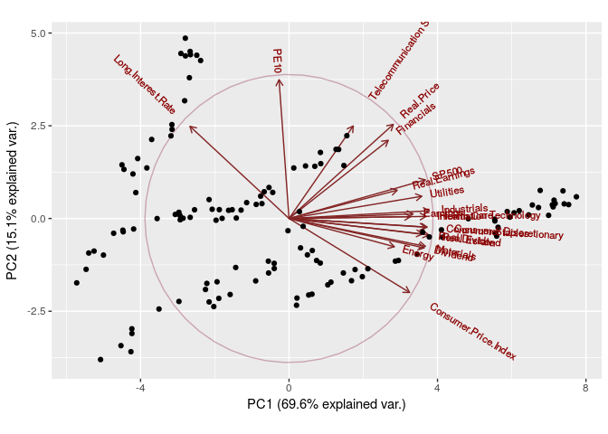

```r
con <- read.csv('constituents.csv',header = T)
idx <- read.csv('indexes.csv',header = T)
all_cmp %>% select(cp_n,Open,Date) -> op_sector
merge(x=op_sector , y =con ,by.x = 'cp_n',by.y = "Symbol") -> r
r %>% group_by(Sector,Date)  %>%
  summarise(mp=mean(Open)) -> mean_open_type
mean_type_mat <- acast(mean_open_type, Date~Sector, value.var="mp")
mean_type_mat <- as.data.frame(mean_type_mat)
mean_type_mat$Date = rownames(mean_type_mat)
idx_merged <- merge(x=mean_type_mat , y =idx,by.x = 'Date',by.y = "Date")
drops <- c("Date")
idx_merged<- idx_merged[ , !(names(idx_merged) %in% drops)]

library(ggbiplot)
type.pca = prcomp(as.matrix(idx_merged), scale. = TRUE, center=T)
ggbiplot(type.pca, obs.scale = 1, var.scale = 1, , ellipse = TRUE, circle = TRUE) +
  scale_color_discrete(name = '') +
  theme(legend.direction = 'horizontal', legend.position = 'top')
```

۷. روی همه اطلاعات (OHLCV) سهام اپل الگوریتم PCA را اعمال کنید. سپس از مولفه اول برای پیش بینی قیمت شروع سهام در روز آینده استفاده کنید. به سوالات سوال ۴ پاسخ دهید. آیا استفاده از مولفه اول نتیجه بهتری نسبت به داده open price برای پیش بینی قیمت دارد؟

```r
apple <- all_cmp %>% filter(cp_n=='AAPL') %>% select(Open)
apple_mark <- all_cmp_temp %>% filter(cp_n=='AAPL') %>% select(Open,High,Low,Close,Volume,Adj.Close)
app_mat <- as.matrix(apple_mark)
pca.app = prcomp(app_mat, center=T, scale.=T)
pcs = data.frame(pca.app$x)
app_pca1 <- pcs$PC1

model_res_pca <- rep(0,10)
cols =  paste("x", 1:10, sep = "")
for (k in 1:10){
day_count <- length(app_pca1) - k
day <- data.frame(y=tail(apple,day_count)$Open)
for (j in 1:k){
  lst <- length(app_pca1) - j
  day <-cbind(day,app_pca1[(lst-day_count+1):(lst)])
}
colnames(day) <- c('y',cols[1:k])
linearMod <- lm(y~., data=day)
model_res_pca[k]<- summary(linearMod)$r.squared
}
model_res_pca
```

```
##  [1] 0.9808481 0.9808590 0.9808628 0.9808682 0.9808758 0.9808913 0.9809009
##  [8] 0.9809074 0.9809138 0.9809226
```

۸. نمودار سود نسبی شاخص s&p500 را رسم کنید. آیا توزیع سود نرمال است؟(از داده indexes استفاده کنید.) با استفاده از ده مولفه اول سوال پنج آیا می توانید سود و ضرر شاخص s&p500 را برای روز آينده پیش بینی کنید؟ از یک مدل رگرسیون لاجستیک استفاده کنید. درصد خطای پیش بینی را به دست آورید.

۹. عکسی که در ابتدای متن آمده را در نظر بگیرید. با استفاده از pca عکس را فشرده کنید. سپس نمودار حجم عکس فشرده بر حسب تعداد مولفه اصلی را رسم کنید. بهترین انتخاب برای انتخاب تعداد مولفه ها در جهت فشرده سازی چه عددی است؟

for this analysis I use this site :https://www.r-bloggers.com/image-compression-with-principal-component-analysis/

```r
library(jpeg)
st <- readJPEG('images/stock.jpg')
ncol(st)
```

```
## [1] 620
```

```r
nrow(st)
```

```
## [1] 412
```

```r
r <- st[,,1]
g <- st[,,2]
b <- st[,,3]

st.r.pca <- prcomp(r, center = FALSE)
st.g.pca <- prcomp(g, center = FALSE)
st.b.pca <- prcomp(b, center = FALSE)

rgb.pca <- list(st.r.pca, st.g.pca, st.b.pca)
#### reconstructs the original image using the projections of the data using increasing amounts of principal components
PC_number = data.frame()
for (i in seq.int(3, round(nrow(st) - 10), length.out = 10)) {
  pca.img <- sapply(rgb.pca, function(j) {
    compressed.img <- j$x[,1:i] %*% t(j$rotation[,1:i])
  }, simplify = 'array')
  writeJPEG(pca.img, paste('compressed/', round(i,0), '.jpg', sep = ''))
  PC_number <- rbind(PC_number,i)
}
PC_number
```

```
##           X3
## 1    3.00000
## 2   47.33333
## 3   91.66667
## 4  136.00000
## 5  180.33333
## 6  224.66667
## 7  269.00000
## 8  313.33333
## 9  357.66667
## 10 402.00000
```

compressed images are in compressed folder. now we can get size of each comressed file in here :

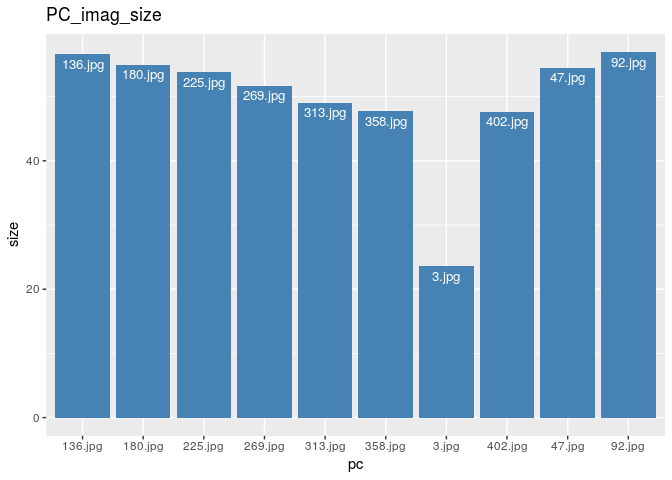

```r
original <- file.info('images/stock.jpg')$size / 1000
imgs <- dir('compressed/')

PC_Vol = data.frame()

for (i in imgs) {
  full.path <- paste('compressed/', i, sep='')
  com_size <- (file.info(full.path)$size)/1000
  PC_Vol <- rbind(PC_Vol,data.frame(pc=i,size=com_size))
}

PC_Vol %>% arrange(-size) %>%  ggplot(aes(x=pc,y=size)) +
  geom_bar(stat="identity", fill="steelblue")+
  geom_text(aes(label=pc), vjust=1.6, color="white", size=3.5)+ ggtitle('PC_imag_size')
```

```r
  theme_minimal()
```

[output not shown]

[output cut: 306 more lines]

[output not shown]

as it can be seen here and in the image quality in compressed folder I choose *402* PC. ***

۱۰. پنج ایده جالبی که روی داده های مالی بالا می توانستیم پیاده کنیم را بیان کنید. (ایده کافی است نیازی به محاسبه بر روی داده نیست.) ایده ها :

1- پیدا کردن بازه هایی که شرکت ها در آن ها رشد و سقوط داشته اند . ۲- در گروه های مختلف می توان بررسی کرد که رشد یک شرکت چه تاثیری بر دیگر اعضای گروه دارد ۳- بیتشرین گردش مالی در کدام بخش هاست و هر بخش در چه سالی بیشترین گردش مالی را دارد و بع چه دلیل ۴- در هر سال خرید از کدام دسته از نیاز ها بیشتر بوده و به چه دلیل ؟ 5- مدلی که برای پیشبینی استفاده میکنیم فقط مربوط به روز های قبل آن شرکت نباید بله قمیت تمامی کالاها را وارد مدل کنیم . ۶- در هر بازه کدام یک از شرکت ها در هر بخش بیشترین سود را کسب میکرده